# Lab 10 - Parallel Computing

# Learning goals

- Evaluate whether a problem can be parallelized.
- Vectorize code before reaching for parallelism.
- Use `joblib.Parallel` to parallelize embarrassingly parallel workloads.
- Measure and compare serial vs parallel execution time (speedup).

# Lab description

In this lab you will practice parallel computing in Python on your own machine. We will test it out on some simulations first, then try XGB on the `cps_clean` data from lab 8.

# Deliverables

Questions 1–3 answered (code + written responses), qmd and html uploaded to Quercus.

## Setup

Check your system

```python
# Uncomment to install
import subprocess
subprocess.run(["pip", "install", "xgboost", "scikit-learn"])
```

```
CompletedProcess(args=['pip', 'install', 'xgboost', 'scikit-learn'], returncode=0)
```

```python
import multiprocessing
import numpy as np
import time
import os
import sys
from joblib import Parallel, delayed

# Session info
import platform
print(f"Python:          {sys.version}")
print(f"Platform:        {platform.platform()}")
print(f"CPUs available:  {multiprocessing.cpu_count()}")
```

```
Python:          3.13.5 (v3.13.5:6cb20a219a8, Jun 11 2025, 12:23:45) [Clang 16.0.0 (clang-1600.0.26.6)]
Platform:        macOS-26.3-arm64-arm-64bit-Mach-O
CPUs available:  10
```

## Problem 1: Identifying parallelizable problems

Take a few minutes to think about what you learned about parallelization.

**1a.** List **three examples** of data science / scientific computing tasks that are well-suited to parallel computing. For each one, briefly explain *why* it is parallelizable (i.e., what makes the sub-tasks independent?).

**Solutions:**

- Bootstrap resampling: Each replicate can be generated and analyzed independently, so one worker can handle one simulation run or bootstrap sample without depending on the others.
- Cross-validation: Each fold can be trained and evaluated separately because fitting a model on one train/test split does not require results from another fold.
- Batch processing of many files or images: If the same preprocessing or feature-extraction pipeline is applied to each file, each item can be processed independently on a different worker.

**1b.** List **one example** of a computation that is **not** easily parallelized, and explain the bottleneck.

Training an Recurrent Neural Network on a sequence is not easily parallelized across time steps because the hidden state at time t depends on the hidden state from time t-1. The bottleneck is this sequential dependency, which means later steps must wait for earlier ones.

**1c.** Look at the code below. Before running it, predict: will parallelizing this loop give a big speedup? Why or why not?

```python
import numpy as np

def dot_products(args):
    a, b = args
    return np.dot(a, b)

rng = np.random.default_rng(42)
pairs = [(rng.standard_normal(1000), rng.standard_normal(1000)) for _ in range(500)]
```

**Prediction:** I would not expect a big speedup. Although the 500 dot products are independent and therefore parallelizable, each individual task is very small, so the overhead of starting workers and passing data between processes may cancel out most of the benefit.

Now time the serial and parallel versions and report the actual speedup.

```python
# Serial
t0 = time.perf_counter()
serial_results = [dot_products(p) for p in pairs]
t_serial = time.perf_counter() - t0

# Parallel — YOUR CODE HERE
# Use Parallel(n_jobs=4)(delayed(dot_products)(p) for p in pairs)
t0 = time.perf_counter()
parallel_results = Parallel(n_jobs=4)(delayed(dot_products)(p) for p in pairs)
t_parallel = time.perf_counter() - t0

print(f"Serial:   {t_serial*1000:.1f} ms")
print(f"Parallel: {t_parallel*1000:.1f} ms")
print(f"Speedup:  {t_serial/t_parallel:.2f}x")
```

```
Serial:   1.6 ms
Parallel: 195.2 ms
Speedup:  0.01x
```

*Was your prediction correct? Explain the result.*

**Solutions:**

Yes, the prediction was correct. On my machine, the serial version took about 1.6 ms, while the parallel version took about 195.2 ms, for a speedup of only 0.01x. So parallelization made the code slower rather than faster. This is because each dot product is a very small task, so the overhead of starting worker processes, scheduling the jobs, and passing data between processes is much larger than the time spent doing the actual computation.

## Problem 2: Comparing Runtime of Models

Before adding parallelism, make sure your code is already efficient. Parallelizing slow serial code just gives you many slow workers.

**2a.** The function below generates an `n × k` matrix where each entry is drawn from a Poisson distribution with mean `lambda`. It builds the matrix row-by-row using `np.vstack`, which is inefficient. Write a faster version `fun1_fast` using a single NumPy call.

```python
import timeit

def fun1(n=100, k=4, lam=4, seed=0):
    rng = np.random.default_rng(seed)
    x = None
    for i in range(n):
        row = rng.poisson(lam, k).reshape(1, -1)
        x = row if x is None else np.vstack([x, row])
    return x

def fun1_fast(n=100, k=4, lam=4, seed=0):
    # YOUR CODE HERE — use a single rng.poisson call
    rng = np.random.default_rng(seed)
    return rng.poisson(lam, size=(n, k))

# Verify same shape
assert fun1().shape == fun1_fast().shape, "Shape mismatch!"

# Benchmark
t_slow = timeit.timeit(lambda: fun1(), number=50)
t_fast = timeit.timeit(lambda: fun1_fast(), number=50)
print(f"fun1:      {t_slow*1000/50:.2f} ms per call")
print(f"fun1_fast: {t_fast*1000/50:.2f} ms per call")
print(f"Speedup:   {t_slow/t_fast:.1f}x")
```

```
fun1:      0.18 ms per call
fun1_fast: 0.02 ms per call
Speedup:   8.3x
```

*How much faster is your version? Explain briefly why.*

**Solutions:**

`fun1_fast` is about 8.3x faster than `fun1` on my machine (about 0.02 ms per call versus 0.18 ms per call). It is faster because it generates the entire `n x k` matrix in one vectorized NumPy call instead of repeatedly growing the matrix row-by-row with `np.vstack`, which creates extra copying overhead.

**2b.** The function below finds the **row index of the maximum value** in each column of a matrix using a Python loop. Write a faster vectorized version using NumPy.

```python
rng = np.random.default_rng(1234)
x = rng.standard_normal((10, 10_000))

def fun2(x):
    result = []
    for j in range(x.shape[1]):
        result.append(np.argmax(x[:, j]))
    return np.array(result)

def fun2_fast(x):
    # YOUR CODE HERE — hint: np.argmax has an axis argument
    return np.argmax(x, axis=0)

# Verify
assert np.array_equal(fun2(x), fun2_fast(x)), "Results differ!"

t_slow = timeit.timeit(lambda: fun2(x), number=20)
t_fast = timeit.timeit(lambda: fun2_fast(x), number=20)
print(f"fun2:      {t_slow*1000/20:.2f} ms per call")
print(f"fun2_fast: {t_fast*1000/20:.2f} ms per call")
print(f"Speedup:   {t_slow/t_fast:.1f}x")
```

```
fun2:      8.80 ms per call
fun2_fast: 0.13 ms per call
Speedup:   65.4x
```

*Report the speedup and explain.*

**Solutions:**

`fun2_fast` is about 65.4x faster than `fun2` (about 0.13 ms per call versus 8.8 ms per call). It is faster because `np.argmax(x, axis=0)` performs the work in optimized NumPy code over the whole array at once, instead of looping through columns in Python and calling `np.argmax` repeatedly.

## Problem 3: Parallel XGBoost Hyperparameter Search

Hyperparameter tuning via grid search is a classic **embarrassingly parallel** task: every combination of hyperparameters can be trained and evaluated completely independently. We will use the **CPS dataset** from Lab 8 (select 2025 only) and train XGBoost classifiers to predict whether an individual is employed.

### Data preparation

Run this cell as-is (no changes needed):

```python
import pandas as pd
import xgboost as xgb
from sklearn.model_selection import train_test_split, cross_val_score
from sklearn.metrics import roc_auc_score
import matplotlib.pyplot as plt

cps = pd.read_csv("https://raw.githubusercontent.com/JSC370/JSC370-2026/main/data/cps_clean.csv")
cps = cps[cps['YEAR'].isin([2025])]

# Binary outcome: 1 = employed, 0 = unemployed
cps['employed'] = (cps['worker_cat'] != 'Unemployed').astype(int)

# create race variables
cps_enc = pd.get_dummies(cps, columns=['race_cat'], drop_first=True)

# select features available before observing employment status
feature_cols = ['AGE', 'female', 'married', 'educ_cat',
                'metro_binary', 'us_citizen', 'has_children', 'NCHILD',
                'race_cat_Black', 'race_cat_Other', 'race_cat_White']

X = cps_enc[feature_cols].fillna(0).values.astype(float)
y = cps_enc['employed'].values.astype(int)

X_train, X_test, y_train, y_test = train_test_split(
    X, y, test_size=0.3, random_state=42
)
print(f"Train: {X_train.shape},  Test: {X_test.shape}")
print(f"Employment rate (overall): {y.mean():.3f}")
print(f"Employment rate (train):   {y_train.mean():.3f}")
```

```
Train: (33913, 11),  Test: (14535, 11)
Employment rate (overall): 0.954
Employment rate (train):   0.955
```

### Hyperparameter grid

- Fill in three values for each of these hyperparameters: `max_depth`, `learning_rate`, `n_estimators`, `subsample`

```python
# All combinations — 81 total
param_grid = [
    {'max_depth': d, 'learning_rate': lr, 'n_estimators': n, 'subsample': ss}
    for d in [3, 5, 7]
    for lr in [0.01, 0.1, 0.3]
    for n in [50, 100, 200]
    for ss in [0.6, 0.8, 1.0]
]

# This will give us 81 total combinations as intended.

print(f"Total hyperparameter combinations: {len(param_grid)}")
```

```
Total hyperparameter combinations: 81
```

**3a.** Complete the `fit_xgb` function below. Use **5-fold cross-validation on the training set** to evaluate each hyperparameter combination — this is the correct way to do hyperparameter search, since it avoids overfitting to a single train/test split. The held-out test set is reserved for final evaluation only (see 3c).

Note: set `n_jobs=1` on both the XGBoost model and `cross_val_score` — parallelism comes from running multiple combinations simultaneously via `joblib`, not from internal threading.

```python
def fit_xgb(params):
    """Evaluate one hyperparameter combination via 5-fold CV."""
    # YOUR CODE HERE
    # 1. Build an XGBClassifier with the given params, n_jobs=1,
    #    eval_metric='logloss', random_state=42, verbosity=0
    # 2. Run cross_val_score with cv=5, scoring='roc_auc', n_jobs=1 on (X_train, y_train)
    # 3. Return (params, scores.mean())
    model = xgb.XGBClassifier(
        **params,
        n_jobs=1,
        eval_metric='logloss',
        random_state=42,
        verbosity=0
    )
    scores = cross_val_score(
        model,
        X_train,
        y_train,
        cv=5,
        scoring='roc_auc',
        n_jobs=1
    )
    return (params, scores.mean())

# Serial grid search
t0 = time.time()
serial_results = [fit_xgb(p) for p in param_grid]
time_serial = time.time() - t0
print(f"Serial grid search: {time_serial:.2f}s  ({len(param_grid)} combinations)")
```

```
Serial grid search: 40.45s  (81 combinations)
```

**3b.** Parallelize the grid search using `joblib.Parallel` with **4 workers**. Measure the wall-clock time and compute the speedup.

```python
t0 = time.time()
# YOUR CODE HERE
# Use: Parallel(n_jobs=4)(delayed(fit_xgb)(p) for p in param_grid)
parallel_results = Parallel(n_jobs=4)(delayed(fit_xgb)(p) for p in param_grid)
time_parallel = time.time() - t0

print(f"Parallel grid search (4 workers): {time_parallel:.2f}s")
print(f"Speedup: {time_serial / time_parallel:.2f}x")
```

```
Parallel grid search (4 workers): 12.50s
Speedup: 3.24x
```

**3c.** Verify the serial and parallel CV AUC scores match, report the best hyperparameter combination, then refit the best model on the full training set and evaluate once on the held-out test set.

```python
# YOUR CODE HERE
# 1. Extract mean CV AUC lists from serial_results and parallel_results
# 2. Assert they are close with np.allclose(..., atol=1e-6)
# 3. Find the entry in parallel_results with the highest mean CV AUC
# 4. Refit an XGBClassifier with best params on X_train, evaluate on X_test
#    using roc_auc_score — this is the final unbiased test performance
serial_scores = [score for _, score in serial_results]
parallel_scores = [score for _, score in parallel_results]

assert np.allclose(serial_scores, parallel_scores, atol=1e-6), "Serial and parallel results differ!"

best_params, best_cv_auc = max(parallel_results, key=lambda x: x[1])

best_model = xgb.XGBClassifier(
    **best_params,
    n_jobs=1,
    eval_metric='logloss',
    random_state=42,
    verbosity=0
)
best_model.fit(X_train, y_train)

y_test_pred = best_model.predict_proba(X_test)[:, 1]
test_auc = roc_auc_score(y_test, y_test_pred)

print(f"Best params: {best_params}")
print(f"Best mean CV AUC: {best_cv_auc:.4f}")
print(f"Test AUC: {test_auc:.4f}")
```

```
Best params: {'max_depth': 3, 'learning_rate': 0.1, 'n_estimators': 50, 'subsample': 1.0}
Best mean CV AUC: 0.6937
Test AUC: 0.6989
```

**3d.** Experiment with 1, 2, 4, and `multiprocessing.cpu_count()` workers. Print a timing table and plot speedup vs number of workers.

```
workers=1: 41.50s  speedup=0.97x
workers=2: 22.77s  speedup=1.78x
workers=4: 12.27s  speedup=3.30x
workers=9: 8.14s  speedup=4.97x
```

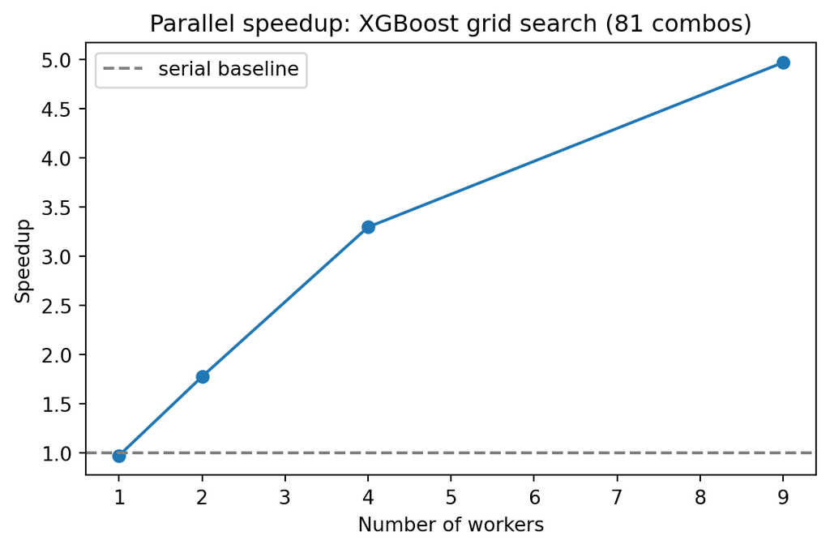

```python
worker_counts = [1, 2, 4, multiprocessing.cpu_count() - 1]
times = {}

for n_workers in worker_counts:
    t0 = time.time()
    Parallel(n_jobs=n_workers)(delayed(fit_xgb)(p) for p in param_grid)
    times[n_workers] = time.time() - t0
    print(f"workers={n_workers}: {times[n_workers]:.2f}s  "
          f"speedup={time_serial / times[n_workers]:.2f}x")

fig, ax = plt.subplots(figsize=(6, 4))
ax.plot(list(times.keys()), [time_serial / t for t in times.values()], marker='o')
ax.axhline(1, color='gray', linestyle='--', label='serial baseline')
ax.set_xlabel("Number of workers")
ax.set_ylabel("Speedup")
ax.set_title(f"Parallel speedup: XGBoost grid search ({len(param_grid)} combos)")
ax.legend()
plt.tight_layout()
plt.show()
```

*Does speedup scale linearly with the number of workers? Why or why not? What overhead is present even in an embarrassingly parallel task like this?*

**Solutions:**

No, the speedup does not scale linearly with the number of workers. The runtime improved as workers increased, but the gains became smaller: about 0.97x at 1 worker, 1.78x at 2 workers, 3.3x at 4 workers, and 4.97x at 9 workers. This happens because even an embarrassingly parallel task still has overhead from starting worker processes, scheduling jobs, sending data to workers, and collecting results. There is also contention for shared CPU and memory resources, so adding more workers eventually gives diminishing returns.